# Hypothesis Testing

### Example 14: Let us come back to Example 11.

We already use the `puerto` data set. Let’s us see if we can say that the median of Puerto Rican immigrants to Miami’s income is equal to $273$.

What is the appropriate test for center?

Let’s first check if the distribution of the observed random variable is normal.

$H_0: X$ is normally distributed

$H_A: X$ isn’t normally distributed

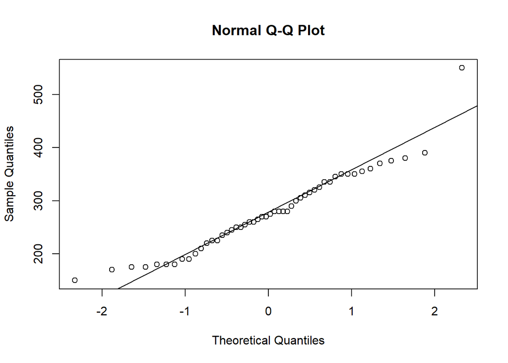

```r
> qqnorm(puerto)
> qqline(puerto)
```

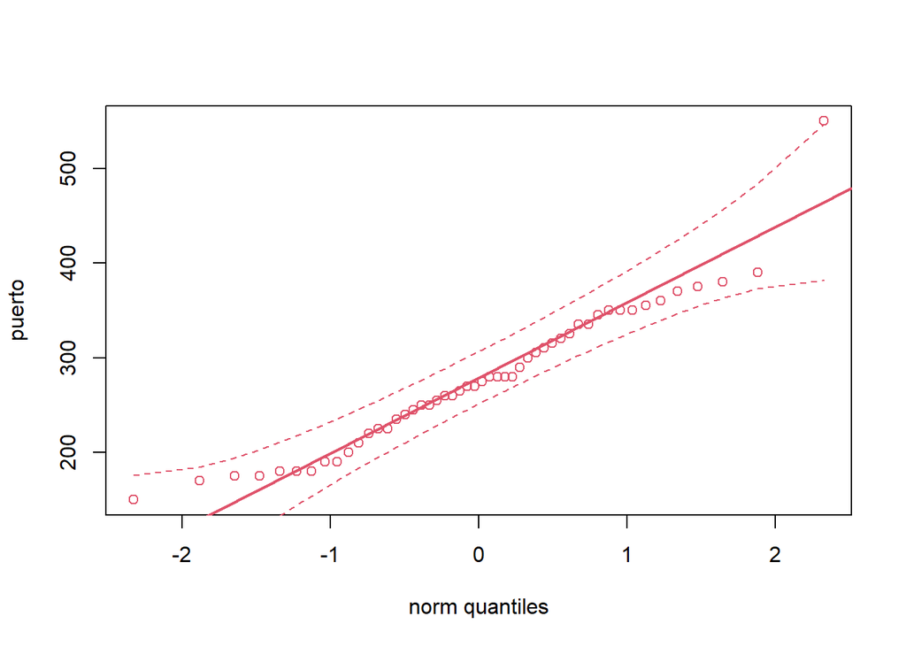

```r
> qqplot.das(puerto)
```

```r
> shapiro.test(puerto)

    Shapiro-Wilk normality test

data:  puerto
W = 0.94538, p-value = 0.02212
```

```r
> wilcox.test(puerto, mu = 273, alternative = "two.sided")

    Wilcoxon signed rank test with continuity correction

data:  puerto
V = 642, p-value = 0.9692
alternative hypothesis: true location is not equal to 273
```

The $p-value = 0.9692 > 0.05 = \alpha$. The sample isn’t in the critical area for the null hypothesis, so we have no reason to reject $H_0$.